# Curs d’introducció a R

17 de juny de 2019

## Què és un model predictiu

- Fins ara hem estat fent **test d’hipòtesis**.
- És a dir, hem analitzat si, amb les dades que teníem, podíem refutar les hipòtesis nul·les i acceptar les nostres hipòtesis (alternatives).
- Ara volem anar més enllà i poder **predir** el resultat de nous experiments.
- Per fer-ho hem de construir un **model** amb les nostres dades.
- Aplicarem el model a noves dades per conèixer-ne les prediccions.

## Tipus de models predictius

- N’hi ha moltissims: regressions, arbres, SVM, randomForests, etc
- Una manera de classificar-los és segons la seva linealitat.
- Què vol dir això?

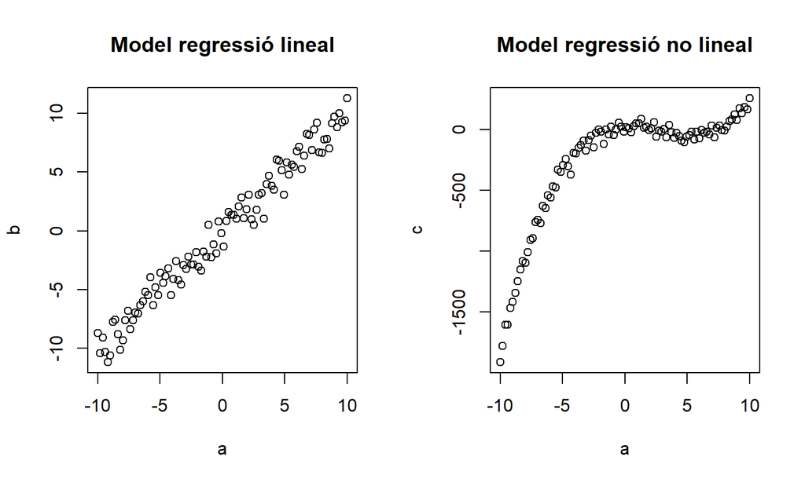

## En classificació

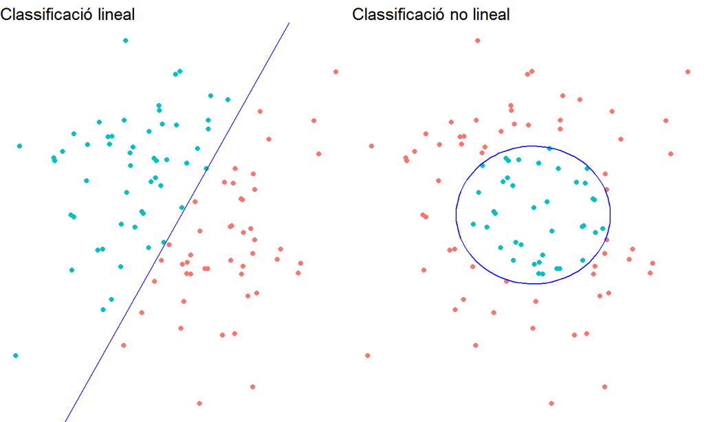

## Regressió lineal

- Mètode molt simple -> sovint simple és bo!
- Assumim un model: \[Y=\beta_0 + \beta_1X+\epsilon\]
- Estimem els coeficients segons les nostres dades: \[\widehat{y}=\hat{\beta_0} + \hat{\beta_1}x\]

On \(\widehat{y}\) és una predicció de Y en el punt \(X=x\).

## Com es troben els coeficients?

- Ajust per mínims quadrats

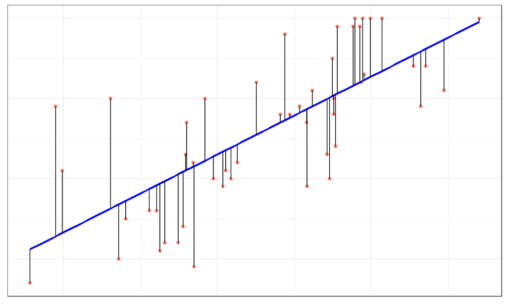

## Regressió multivariant

- Evidentment, la regressió pot tenir més d’una variable predictora \[Y=\beta_0 + \beta_1X_1+ \beta_2X_2+\ldots + \beta_nX_n+ \epsilon\]
- \(\beta_i\) és la variació d’Y amb una unitat d’\(X_i\) *mantenint totes les altres variables fixades*
- Alerta amb correlacions entre dades, ens poden jugar una mala passada.
  - La variància dels coeficients augmenta.
  - Difícil interpretació: no varia una variable \(X_i\) sola.
  - La causalitat se’n ressent.
  - Passa “sovint” en medicina: e.g. tinc el pes en kg i en categories OMS.

## Regressió lineal en R - Univariant

```r
model1 = lm(Total_Protiens~Albumin, data = liver)
summary(model1)
```

```
##
## Call:
## lm(formula = Total_Protiens ~ Albumin, data = liver)
##
## Residuals:
##     Min      1Q  Median      3Q     Max
## -2.3933 -0.4266 -0.0556  0.4461  3.9194
##
## Coefficients:
##             Estimate Std. Error t value Pr(>|t|)
## (Intercept)  3.13777    0.11346   27.66   <2e-16 ***
## Albumin      1.06698    0.03507   30.42   <2e-16 ***
## ---
## Signif. codes:  0 '***' 0.001 '**' 0.01 '*' 0.05 '.' 0.1 ' ' 1
##
## Residual standard error: 0.6747 on 581 degrees of freedom
## Multiple R-squared:  0.6143, Adjusted R-squared:  0.6137
## F-statistic: 925.5 on 1 and 581 DF,  p-value: < 2.2e-16
```

## Condicions per poder fer una regressió

```
##
## Call:
## lm(formula = liver$Alkaline_Phosphotase ~ liver$Alamine_Aminotransferase)
##
## Residuals:
##     Min      1Q  Median      3Q     Max
## -417.46 -110.51  -78.10    4.81 1824.89
##
## Coefficients:
##                                 Estimate Std. Error t value Pr(>|t|)
## (Intercept)                    277.08177   10.92406  25.364  < 2e-16 ***
## liver$Alamine_Aminotransferase   0.16719    0.05475   3.054  0.00236 **
## ---
## Signif. codes:  0 '***' 0.001 '**' 0.01 '*' 0.05 '.' 0.1 ' ' 1
##
## Residual standard error: 241.2 on 581 degrees of freedom
## Multiple R-squared:  0.0158, Adjusted R-squared:  0.0141
## F-statistic: 9.324 on 1 and 581 DF,  p-value: 0.002365
```

```
##
## Call:
## lm(formula = log10(liver$Alkaline_Phosphotase) ~ log10(liver$Alamine_Aminotransferase))
##
## Residuals:
##      Min       1Q   Median       3Q      Max
## -0.55877 -0.12595 -0.05181  0.07534  0.92814
##
## Coefficients:
##                                       Estimate Std. Error t value Pr(>|t|)
## (Intercept)                            2.05937    0.03833  53.727   <2e-16
## log10(liver$Alamine_Aminotransferase)  0.20031    0.02288   8.757   <2e-16
##
## (Intercept)                           ***
## log10(liver$Alamine_Aminotransferase) ***
## ---
## Signif. codes:  0 '***' 0.001 '**' 0.01 '*' 0.05 '.' 0.1 ' ' 1
##
## Residual standard error: 0.2158 on 581 degrees of freedom
## Multiple R-squared:  0.1166, Adjusted R-squared:  0.1151
## F-statistic: 76.68 on 1 and 581 DF,  p-value: < 2.2e-16
```

## Visualització

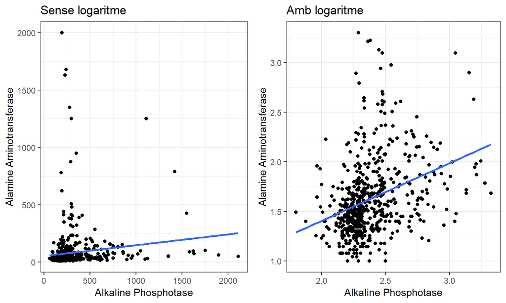

## Regressió multivariant

```r
model2 = lm(Total_Protiens~.-Dataset, data = temp_liver); summary(model2)
```

```
##
## Call:
## lm(formula = Total_Protiens ~ . - Dataset, data = temp_liver)
##
## Residuals:
##     Min      1Q  Median      3Q     Max
## -2.2962 -0.3936 -0.0314  0.3973  3.6711
##
## Coefficients:
##                              Estimate Std. Error t value Pr(>|t|)
## (Intercept)                 1.8764200  0.3468788   5.409 9.29e-08 ***
## Age                         0.0005667  0.0016888   0.336 0.737324
## GenderMale                 -0.0810302  0.0624577  -1.297 0.195027
## Total_Bilirubin             0.1968378  0.0322886   6.096 1.99e-09 ***
## Alkaline_Phosphotase        0.2146984  0.0548472   3.914 0.000101 ***
## Alamine_Aminotransferase   -0.2376804  0.0558046  -4.259 2.40e-05 ***
## Aspartate_Aminotransferase  0.1410403  0.0525988   2.681 0.007541 **
## Albumin                     1.1818941  0.0361559  32.689  < 2e-16 ***
## ---
## Signif. codes:  0 '***' 0.001 '**' 0.01 '*' 0.05 '.' 0.1 ' ' 1
##
## Residual standard error: 0.6302 on 575 degrees of freedom
## Multiple R-squared:  0.6669, Adjusted R-squared:  0.6629
## F-statistic: 164.5 on 7 and 575 DF,  p-value: < 2.2e-16
```

## RM - Colinealitats

```
##
## Call:
## lm(formula = Total_Protiens ~ . - Dataset, data = liver)
##
## Residuals:
##     Min      1Q  Median      3Q     Max
## -2.3273 -0.2343 -0.0387  0.1703  4.8975
##
## Coefficients:
##                              Estimate Std. Error t value Pr(>|t|)
## (Intercept)                 3.1007107  0.2802543  11.064  < 2e-16 ***
## Age                        -0.0007229  0.0012594  -0.574    0.566
## GenderMale                  0.0025249  0.0471025   0.054    0.957
## Total_Bilirubin             0.1673058  0.0749603   2.232    0.026 *
## Direct_Bilirubin           -0.0017070  0.0570839  -0.030    0.976
## Alkaline_Phosphotase        0.0240223  0.0417766   0.575    0.566
## Alamine_Aminotransferase   -0.2410293  0.0416379  -5.789 1.17e-08 ***
## Aspartate_Aminotransferase  0.1656462  0.0392536   4.220 2.84e-05 ***
## Albumin                     1.6698474  0.0353393  47.252  < 2e-16 ***
## Albumin_and_Globulin_Ratio -1.8798116  0.0869677 -21.615  < 2e-16 ***
## ---
## Signif. codes:  0 '***' 0.001 '**' 0.01 '*' 0.05 '.' 0.1 ' ' 1
##
## Residual standard error: 0.4682 on 569 degrees of freedom
##   (4 observations deleted due to missingness)
## Multiple R-squared:  0.8166, Adjusted R-squared:  0.8137
## F-statistic: 281.5 on 9 and 569 DF,  p-value: < 2.2e-16
```

## RM - Intervals de confiança I

```r
ci = confint(model2)
sum = summary(model2)
resum = as.data.frame(cbind(ci[,1], sum$coefficients[,1],
                            ci[,2],sum$coefficients[,4]))
resum = round(resum, 3)
colnames(resum) = c("IC-", "Coeficient", "IC+", "p-valor")
resum
```

```
##                               IC- Coeficient    IC+ p-valor
## (Intercept)                 1.195      1.876  2.558   0.000
## Age                        -0.003      0.001  0.004   0.737
## GenderMale                 -0.204     -0.081  0.042   0.195
## Total_Bilirubin             0.133      0.197  0.260   0.000
## Alkaline_Phosphotase        0.107      0.215  0.322   0.000
## Alamine_Aminotransferase   -0.347     -0.238 -0.128   0.000
## Aspartate_Aminotransferase  0.038      0.141  0.244   0.008
## Albumin                     1.111      1.182  1.253   0.000
```

## RM - Intervals de confiança II

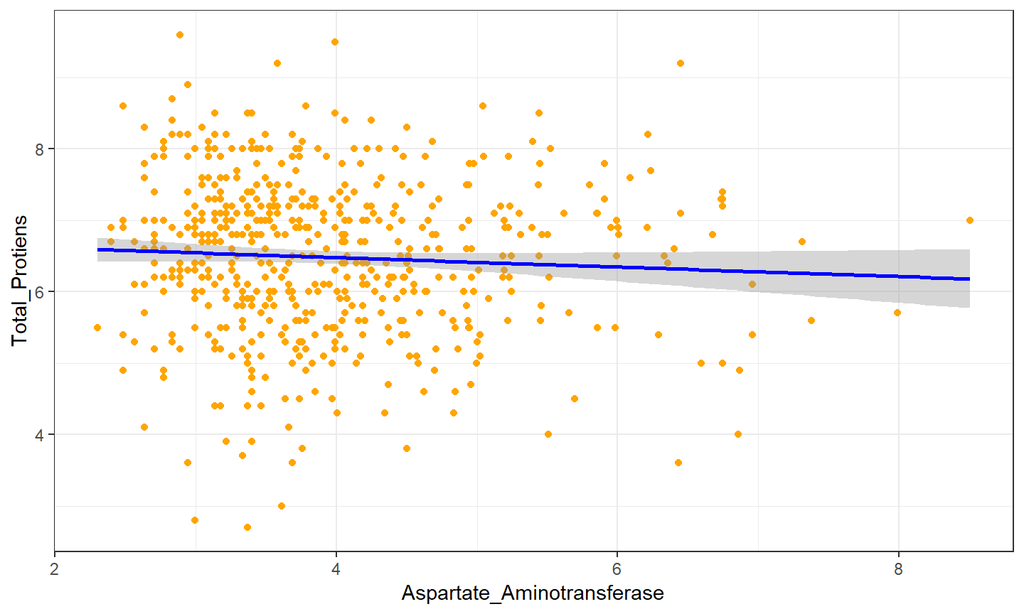

## Regressió logística

- Per què cal?

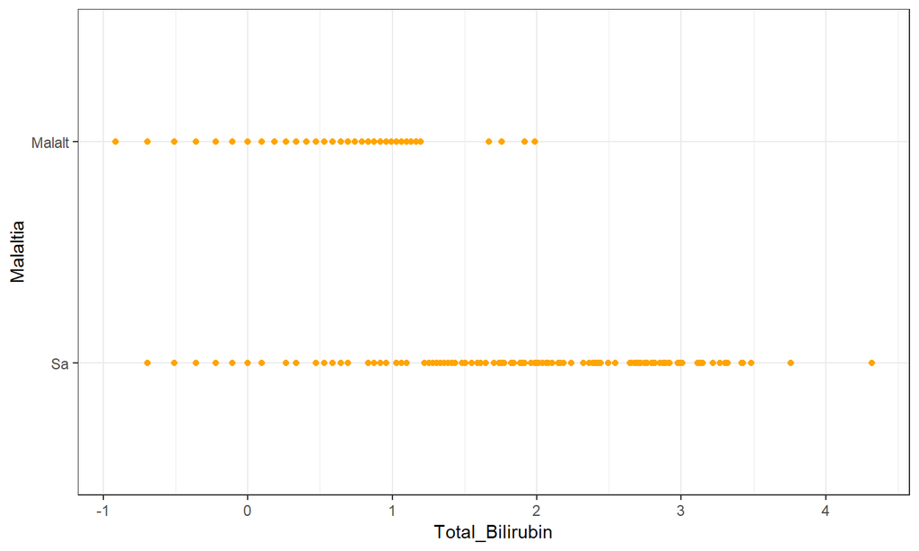

## Regressió lineal

\[Y= \beta_0 + \beta_1 X+\epsilon\]

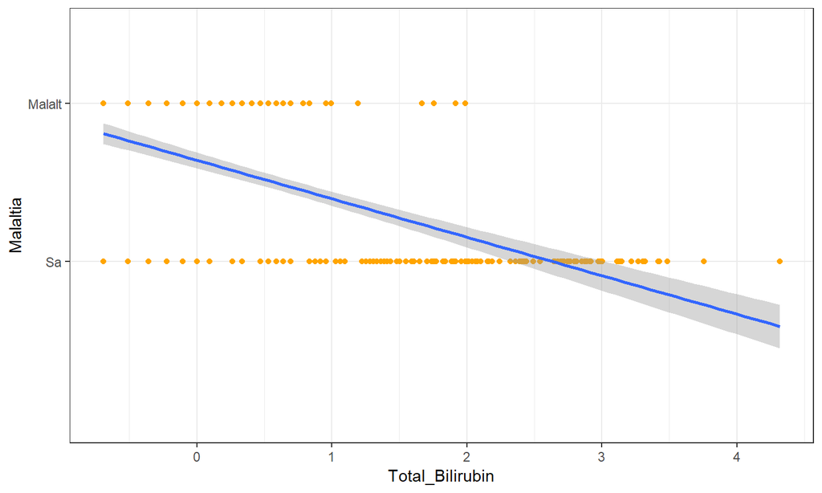

## Regressió logística

\[\phantom{aa} Y = \frac{1}{1+e^{-(\beta_o+\beta_1X+\epsilon)}}\]

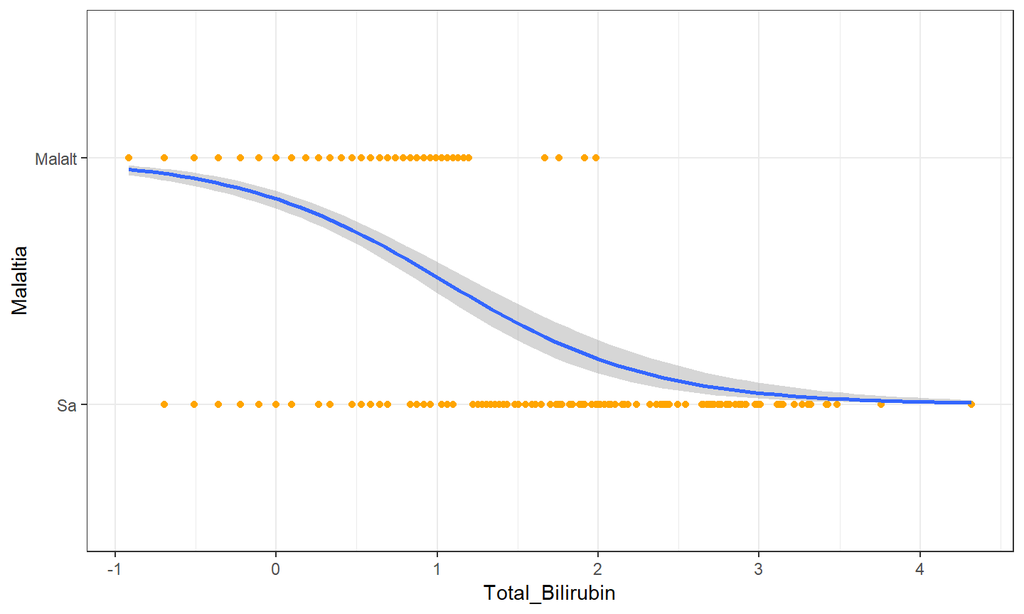

## Regressió logística en R

```r
model4 = glm(Malaltia~., data=tl, family="binomial"); summary(model4)
```

```
##
## Call:
## glm(formula = Malaltia ~ ., family = "binomial", data = tl)
##
## Deviance Residuals:
##     Min       1Q   Median       3Q      Max
## -2.3248  -0.4319   0.4876   0.5995   1.8158
##
## Coefficients:
##                       Estimate Std. Error z value Pr(>|z|)
## (Intercept)           0.896938   1.468251   0.611    0.541
## Age                   0.004604   0.007325   0.628    0.530
## GenderMale            0.007119   0.276802   0.026    0.979
## Total_Bilirubin      -1.523542   0.153368  -9.934   <2e-16 ***
## Alkaline_Phosphotase  0.095777   0.227440   0.421    0.674
## Total_Protiens       -0.158334   0.182043  -0.870    0.384
## Albumin               0.314754   0.260155   1.210    0.226
## ---
## Signif. codes:  0 '***' 0.001 '**' 0.01 '*' 0.05 '.' 0.1 ' ' 1
##
## (Dispersion parameter for binomial family taken to be 1)
##
##     Null deviance: 730.08  on 582  degrees of freedom
## Residual deviance: 514.45  on 576  degrees of freedom
## AIC: 528.45
##
## Number of Fisher Scoring iterations: 5
```

## RL - Intervals de confiança

- Podem fer igual que en la regressió lineal:

```
##                         IC- Coeficient    IC+ p-valor
## (Intercept)          -1.999      0.897  3.770   0.541
## Age                  -0.010      0.005  0.019   0.530
## GenderMale           -0.546      0.007  0.543   0.979
## Total_Bilirubin      -1.838     -1.524 -1.236   0.000
## Alkaline_Phosphotase -0.343      0.096  0.551   0.674
## Total_Protiens       -0.519     -0.158  0.196   0.384
## Albumin              -0.191      0.315  0.831   0.226
```

- En el cas del gènere puc calcular l’Odd Ratio i els seus IC:

```r
odd_r = exp(resum[3,1:3])
colnames(odd_r) = c("OR IC-", "Odd Ratio", "OR IC+"); odd_r
```

```
##               OR IC- Odd Ratio   OR IC+
## GenderMale 0.5792622  1.007025 1.721163
```

## Prediccions

- Hem calculat els models, ara ja podem fer prediccions
- S’acosutma a reservar una part de les dades per provar el model que hem construït en la resta
- D’aquesta manera ens assegurem que no tenim “overfitting”
  - En parlarem més endavant
- En R gairebé tots els models poden implementar el mètode “predict” per predir el resultat d’aplicar el model en noves dades

## Predicció en regressió lineal

```r
train = sample(nrow(liver), round(nrow(liver)/5*4,0))
test = -train
model_lineal = lm(Total_Protiens~.-Malaltia, data=liver[train,])
preds = predict(model_lineal ,newdata = liver[test,],
                interval ="confidence")
head(preds)
```

```
##         fit      lwr      upr
## 5  6.551060 6.419311 6.682809
## 10 6.742326 6.658047 6.826604
## 16 5.020337 4.862737 5.177937
## 20 6.442082 6.288328 6.595836
## 22 6.205920 6.096239 6.315601
## 27 5.330520 5.152942 5.508099
```

Podem dibuixar com de bé ho hem fet:

## Representació dels predictors

Gens malament:

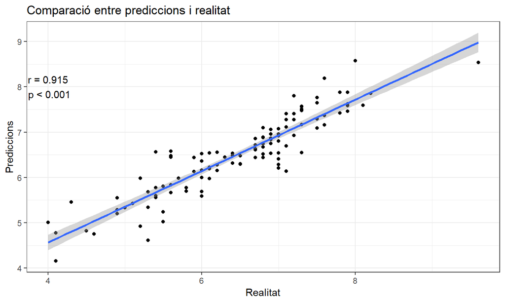

## Predictors en regressió logística

```r
model_log = glm(Malaltia~., data=liver[train,], family = "binomial")
probs = predict(model_log ,newdata = liver[test,], type = "response")
preds = rep(0, length(test))
preds = ifelse(probs>0.5,1,0)
tt = table(liver$Malaltia[test], preds,
           dnn=c("Realitat", "Prediccions"))
#La matriu de confusió és:
tt
```

```
##         Prediccions
## Realitat  0  1
##        0 17 16
##        1  5 78
```

```r
print(paste0("I la ràtio d'encert és ", round((tt[1]+tt[4])/sum(tt),2)))
```

```
## [1] "I la ràtio d'encert és 0.82"
```

## Paràmetres d’avaluació

[figure not shown]

\[Sensibilitat = \frac{VP}{VP+FN}\] \[Especificitat =\frac{VN}{VN+FP} \]

## Corba ROC

- Controlem aquests valors a través del llindar de decisió.
- Hem fixat que predíem malalt quan la RL predís \(p(y)>0.5\), però potser ens interessaria un altre valor.

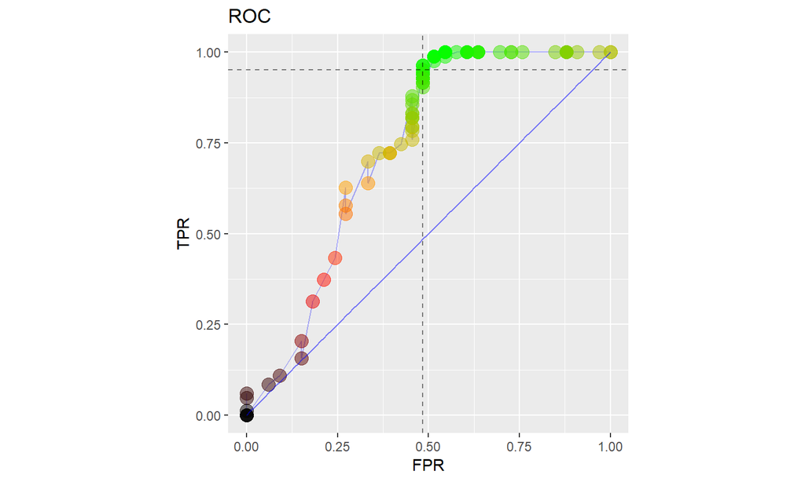

## Una altra forma de veure-ho

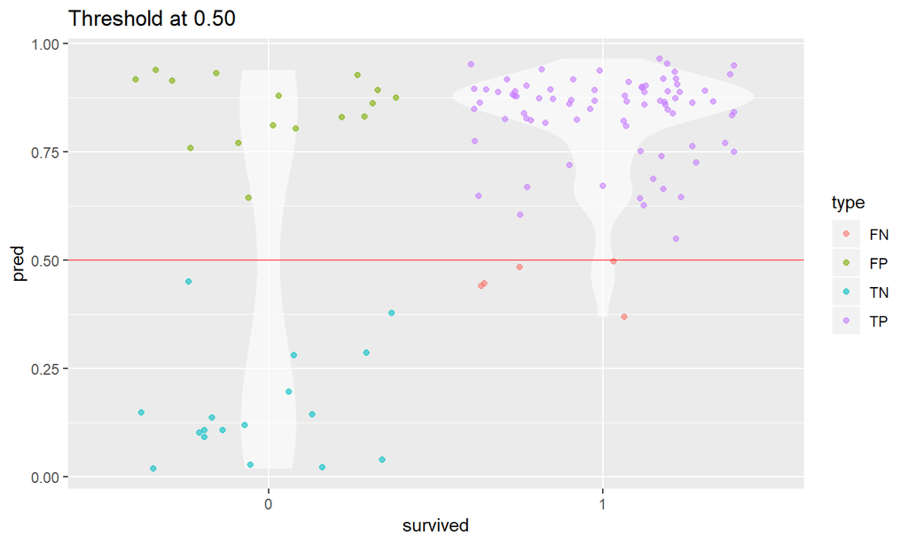

## Àrea sota la corba (AUC)

- Per tenir un sol valor sobre la qualitat general del model calculem l’àrea sota tota la corba ROC.
- Un model aleatori tindria una AUC = 0.5
- Un model perfecte tindria una AUC = 1

La calculem:

```
## $cvAUC
## [1] 0.7301935
##
## $se
## [1] 0.06085749
##
## $ci
## [1] 0.610915 0.849472
##
## $confidence
## [1] 0.95
```